# Cross-Study Plant Allometry — SMA/RMA Scaling Exponents

# 5 AGB ~ DBH: SMA exponents per source

Available sources with both AGB and DBH: BAAD (direct measurement) and NEON ForestAGB (Chojnacky model-derived).

> **AGB note:** NEON AGB values are estimated from DBH via Chojnacky et al. (2014). The AGB~DBH relationship for NEON largely reflects the embedded allometric equations, not independent biomass data.

```r
# ── Purpose of this chunk ─────────────────────────────────────────────────────
# Fit SMA AGB ~ DBH for each source and test against the MST/WBE prediction
# β = 8/3 ≈ 2.667 (West, Brown & Enquist 1999; biomass ~ radius³ from pipe model).
#
# Only BAAD and NEON have AGB alongside DBH (Tallo, Nouragues, ForestGEO Panama
# do not provide AGB in the form available here).
#
# ⚠️  BAAD AGB ('m.to' field): field-measured AGB in kg (directly measured).
# ⚠️  NEON AGB ('AGBChojnacky'): computed from DBH via Chojnacky allometric
# equations. NEON AGB is NOT independent of DBH — the regression slope here
# partially reflects the mathematical form of the allometric equation used.
sources_agb <- sort(unique(all_agb$source))

fit_rows_agb <- lapply(sources_agb, function(src) {
  d <- all_agb |> filter(source == src)
  if (nrow(d) < 30) return(NULL)  # skip if too few records for SMA stability

  # slope.test = 8/3 embeds the WBE hypothesis test in the fit object
  fit_mst <- sma(log_AGB ~ log_DBH, data = d, method = "SMA",
                 slope.test = 8/3)   # test H₀: β = 8/3 ≈ 2.667 (MST)
  fit_ols <- lm(log_AGB ~ log_DBH, data = d)
  cf      <- fit_mst$coef[[1]]  # coef matrix; row "slope" has coef and CI

  data.frame(
    source    = src,
    n         = nrow(d),
    SMA_slope = round(cf["slope","coef(SMA)"],  3),
    CI_lo     = round(cf["slope","lower limit"], 3),
    CI_hi     = round(cf["slope","upper limit"], 3),
    OLS_slope = round(coef(fit_ols)[2], 3),
    R2        = round(summary(fit_ols)$r.squared, 3),
    p_vs_MST  = round(fit_mst$slopetest[[1]]$p, 4),  # H₀: β = 8/3
    stringsAsFactors = FALSE
  )
}) |> bind_rows()

kable(fit_rows_agb,
  col.names = c("Source","N","SMA \u03b2","95% CI lo","95% CI hi",
                "OLS \u03b2","R\u00b2","p (vs 8/3 \u2248 2.667)"),
  caption = paste0(
    "SMA log-log AGB ~ DBH exponents. ",
    "MST prediction: \u03b2 = 8/3 \u2248 2.667 (West et al. 1999). ",
    "\u26a0 NEON AGB is model-derived from DBH (not independent)."
  )
)
```

SMA log-log AGB ~ DBH exponents. MST prediction: β = 8/3 ≈ 2.667 (West et al. 1999). ⚠ NEON AGB is model-derived from DBH (not independent).

|  | Source | N | SMA β | 95% CI lo | 95% CI hi | OLS β | R² | p (vs 8/3 ≈ 2.667) |
| --- | --- | --- | --- | --- | --- | --- | --- | --- |
| log_DBH…1 | BAAD | 716 | 2.221 | 2.175 | 2.268 | 2.130 | 0.920 | 0 |
| log_DBH…2 | NEON ForestAGB | 109318 | 2.770 | 2.768 | 2.773 | 2.748 | 0.984 | 0 |

## 5.1 AGB ~ DBH: SMA scatter

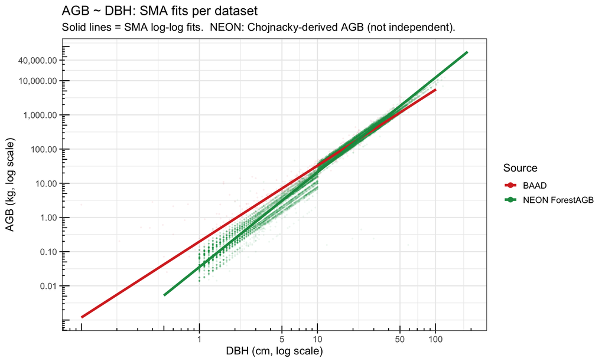

```r
# ── Purpose of this chunk ─────────────────────────────────────────────────────
# Scatter plot of AGB vs DBH for the two sources that have both variables.
# SMA fit lines are generated per source from re-fitted objects (no slope test
# embedded since only the line shape is needed here).
# 20,000 point subsample per source for rendering legibility.
agb_pal <- c("BAAD" = "#d73027", "NEON ForestAGB" = "#1a9850")

sma_lines_agb <- lapply(sources_agb, function(src) {
  d <- all_agb |> filter(source == src)
  if (nrow(d) < 30) return(NULL)
  # Fit without slope.test — we only need the line; slope and CI are in agb-sma-table
  fit <- sma(log_AGB ~ log_DBH, data = d, method = "SMA")
  rng <- range(d$log_DBH)
  xs  <- seq(rng[1], rng[2], length.out = 150)
  cf  <- fit$coef[[1]]
  ys  <- cf["elevation","coef(SMA)"] + cf["slope","coef(SMA)"] * xs
  data.frame(source = src, DBH_cm = exp(xs), AGB_kg = exp(ys))
}) |> bind_rows()

set.seed(42)
agb_sub <- all_agb |>
  group_by(source) |> sample_n(min(20000, n())) |> ungroup()

ggplot(agb_sub, aes(x = DBH_cm, y = AGB_kg, color = source)) +
  geom_point(alpha = 0.05, size = 0.4) +
  geom_line(data = sma_lines_agb,
            aes(x = DBH_cm, y = AGB_kg, color = source),
            linewidth = 1.4, inherit.aes = FALSE) +
  scale_x_log10(labels = comma, breaks = c(1, 5, 10, 50, 100, 300)) +
  scale_y_log10(labels = comma,
                breaks = c(0.01, 0.1, 1, 10, 100, 1000, 10000, 40000)) +
  annotation_logticks() +
  scale_color_manual(values = agb_pal) +
  guides(color = guide_legend(
    override.aes = list(alpha = 1, size = 2.5, linewidth = 1.5),
    title = "Source")) +
  labs(
    x = "DBH (cm, log scale)", y = "AGB (kg, log scale)",
    title = "AGB ~ DBH: SMA fits per dataset",
    subtitle = "Solid lines = SMA log-log fits.  NEON: Chojnacky-derived AGB (not independent)."
  )
```

# 6 AGB ~ Height: Niklas-Enquist + BAAD + NEON

Niklas-Enquist lacks DBH; height is the shared predictor across all three sources.

```r
# ── Purpose of this chunk ─────────────────────────────────────────────────────
# Fit SMA AGB ~ Height for three sources: BAAD, NEON, and Niklas-Enquist.
# Height is the shared predictor because Niklas-Enquist lacks DBH entirely.
# This tests two theoretical predictions:
#   β = 3   (WBE isometric scaling: M ∝ H³ for self-similar branching)
#   β = 8/3 (alternative geometry often seen in empirical datasets)
#
# Procedure:
#   1. Stack BAAD/NEON (from all_agb, filtered to non-NA Height) with niklas_agb_ht.
#   2. Split by source, filter to n ≥ 30.
#   3. Fit two SMA objects per source (different slope.test values).
#   4. Extract slope and CI from fit3 (both fits return the same coef).

agb_ht_all <- bind_rows(
    # BAAD and NEON already have Height_m; convert to log for SMA
    all_agb |> filter(!is.na(Height_m), Height_m > 0) |>
      mutate(log_H = log(Height_m)),
    niklas_agb_ht  # Niklas-Enquist: height_m already assigned in load-data
  )

agb_ht_rows <- agb_ht_all |>
  group_by(source) |>
  filter(n() >= 30) |>   # minimum sample guard
  group_split() |>
  lapply(function(d) {
    src     <- unique(d$source)
    # Two fits needed: one per theoretical exponent to get both p-values
    fit3    <- sma(log_AGB ~ log_H, data = d, method = "SMA", slope.test = 3)
    fit267  <- sma(log_AGB ~ log_H, data = d, method = "SMA", slope.test = 8/3)
    fit_ols <- lm(log_AGB ~ log_H, data = d)
    cf      <- fit3$coef[[1]]  # slope/CI same from either test fit
    data.frame(
      source    = src,
      n         = nrow(d),
      SMA_slope = round(cf["slope","coef(SMA)"],  3),
      CI_lo     = round(cf["slope","lower limit"], 3),
      CI_hi     = round(cf["slope","upper limit"], 3),
      OLS_slope = round(coef(fit_ols)[2], 3),
      R2        = round(summary(fit_ols)$r.squared, 3),
      p_vs_3    = round(fit3$slopetest[[1]]$p, 4),    # H₀: β = 3
      p_vs_267  = round(fit267$slopetest[[1]]$p, 4),  # H₀: β = 8/3
      stringsAsFactors = FALSE
    )
  }) |> bind_rows()

kable(agb_ht_rows,
  col.names = c("Source","N","SMA \u03b2","95% CI lo","95% CI hi",
                "OLS \u03b2","R\u00b2","p (vs 3)","p (vs 8/3)"),
  caption = "SMA log-log AGB ~ Height exponents. Tests: \u03b2 = 3 (isometric) and \u03b2 = 8/3."
)
```

SMA log-log AGB ~ Height exponents. Tests: β = 3 (isometric) and β = 8/3.

|  | Source | N | SMA β | 95% CI lo | 95% CI hi | OLS β | R² | p (vs 3) | p (vs 8/3) |
| --- | --- | --- | --- | --- | --- | --- | --- | --- | --- |
| log_H…1 | BAAD | 716 | 3.215 | 3.101 | 3.333 | 2.798 | 0.757 | 0.0002 | 0 |
| log_H…2 | NEON ForestAGB | 109318 | 3.607 | 3.596 | 3.618 | 3.119 | 0.748 | 0.0000 | 0 |
| log_H…3 | Niklas-Enquist | 433 | 2.882 | 2.806 | 2.960 | 2.764 | 0.920 | 0.0034 | 0 |

# 7 Summary: all SMA exponents

```r
# ── Purpose of this chunk ─────────────────────────────────────────────────────
# Collate the per-source results from the H~DBH and AGB~DBH analyses into one
# comparison table. This is the primary reference table for the manuscript.
# The 'theoretical' column records which prediction was used in the p-test
# so readers understand what each p-value is testing.
hdbh_summ <- sma_hdbh_tab |>
  transmute(relationship = "H ~ DBH", source, n,
            SMA_slope, CI_lo, CI_hi, OLS_slope, R2,
            theoretical = "2/3 (WBE)",  # WBE prediction from West et al. 1999
            p_ref = p_vs_WBE)           # p for H₀: β = 2/3

agb_dbh_summ <- fit_rows_agb |>
  transmute(relationship = "AGB ~ DBH", source, n,
            SMA_slope, CI_lo, CI_hi, OLS_slope, R2,
            theoretical = "8/3 (MST)",  # MST prediction from West et al. 1999
            p_ref = p_vs_MST)           # p for H₀: β = 8/3

summary_all <- bind_rows(hdbh_summ, agb_dbh_summ) |>
  arrange(relationship, desc(n))  # sort within each relationship by sample size

kable(summary_all,
  col.names = c("Relationship","Source","N","SMA \u03b2",
                "CI lo","CI hi","OLS \u03b2","R\u00b2",
                "Theoretical ref.","p (vs ref)"),
  caption = "All SMA allometric exponents \u2014 cross-study summary"
)
```

All SMA allometric exponents — cross-study summary

|  | Relationship | Source | N | SMA β | CI lo | CI hi | OLS β | R² | Theoretical ref. | p (vs ref) |
| --- | --- | --- | --- | --- | --- | --- | --- | --- | --- | --- |
| log_DBH…1 | AGB ~ DBH | NEON ForestAGB | 109318 | 2.770 | 2.768 | 2.773 | 2.748 | 0.984 | 8/3 (MST) | 0.0000 |
| log_DBH…2 | AGB ~ DBH | BAAD | 716 | 2.221 | 2.175 | 2.268 | 2.130 | 0.920 | 8/3 (MST) | 0.0000 |
| log_DBH…3 | H ~ DBH | NEON ForestAGB | 132817 | 0.776 | 0.774 | 0.778 | 0.671 | 0.747 | 2/3 (WBE) | 0.0000 |
| log_DBH…4 | H ~ DBH | Tallo | 80000 | 0.781 | 0.778 | 0.785 | 0.586 | 0.562 | 2/3 (WBE) | 0.0000 |
| log_DBH…5 | H ~ DBH | BAAD | 8272 | 0.789 | 0.783 | 0.796 | 0.731 | 0.858 | 2/3 (WBE) | 0.0000 |
| log_DBH…6 | H ~ DBH | ForestGEO Panama | 5107 | 0.700 | 0.687 | 0.712 | 0.533 | 0.579 | 2/3 (WBE) | 0.0000 |
| log_DBH…7 | H ~ DBH | Nouragues H-D | 888 | 0.645 | 0.619 | 0.673 | 0.495 | 0.588 | 2/3 (WBE) | 0.1328 |

## 7.1 Forest plot

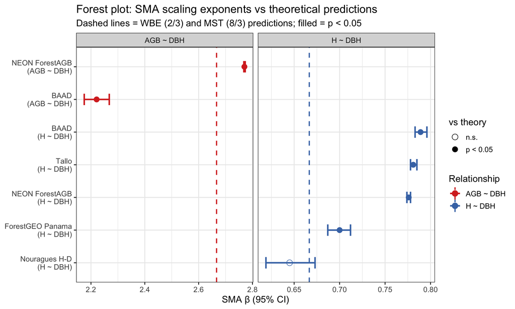

```r
# ── Purpose of this chunk ─────────────────────────────────────────────────────
# Forest plot: all SMA slope estimates with 95% CIs, grouped by relationship.
# Each panel shows estimates for one relationship (H~DBH or AGB~DBH); the
# dashed vertical lines mark the theoretical predictions for that panel.
# Filled circles indicate estimates that differ significantly from theory (p < 0.05);
# open circles indicate no significant difference.
# This is the key visual summary intended for the manuscript or talk.
summary_all |>
  mutate(
    label = paste0(source, "\n(", relationship, ")"),
    sig   = ifelse(p_ref < 0.05, "p < 0.05", "n.s.")  # significant departure from theory?
  ) |>
  ggplot(aes(x = SMA_slope, y = reorder(label, SMA_slope),
             color = relationship, shape = sig)) +
  # One theoretical reference line per facet (different x intercept per relationship)
  geom_vline(data = data.frame(relationship = c("H ~ DBH","AGB ~ DBH"),
                                xint = c(2/3, 8/3)),
             aes(xintercept = xint, color = relationship),
             linetype = "dashed", linewidth = 0.8, inherit.aes = FALSE) +
  geom_errorbarh(aes(xmin = CI_lo, xmax = CI_hi),
                 height = 0.35, linewidth = 1) +  # 95% CI from smatr
  geom_point(size = 3.5) +
  scale_color_manual(values = c("H ~ DBH" = "#4575b4", "AGB ~ DBH" = "#d73027"),
                     name = "Relationship") +
  scale_shape_manual(values = c("p < 0.05" = 16, "n.s." = 1),  # filled vs open
                     name = "vs theory") +
  facet_wrap(~ relationship, scales = "free_x", ncol = 2) +  # free x-axis per panel
  labs(
    x = "SMA \u03b2 (95% CI)", y = NULL,
    title = "Forest plot: SMA scaling exponents vs theoretical predictions",
    subtitle = "Dashed lines = WBE (2/3) and MST (8/3) predictions; filled = p < 0.05"
  )
```

# 8 Caveats

1. **SMA vs RMA:** `smatr::sma()` implements SMA (Standardised Major Axis). True RMA (Reduced Major Axis) assumes equal error variances in both variables; SMA does not. For allometric work on log-transformed data, SMA is the standard choice (Warton et al. 2006).
2. **OLS vs SMA:** OLS minimises only y-residuals and underestimates the slope when both variables carry error — typically by a factor of $1/\sqrt{R^2}$ relative to the true slope. For low-R² allometries the difference is substantial.
3. **Source heterogeneity:** Mixing sources with different measurement protocols, size ranges, and biomes inflates variance and may shift the pooled SMA slope.
4. **NEON AGB is model-derived:** AGB ~ DBH for NEON reflects the Chojnacky equations, not independent data.
5. **Tallo subsampled:** 80,000 of 498,838 records used for fitting; seed 42.
6. **Pooled test p-values:** With large N, even trivial deviations from theoretical predictions will be statistically significant.

# 9 References

- Warton, D.I., Wright, I.J., Falster, D.S. & Westoby, M. (2006). Bivariate line-fitting methods for allometry. *Biological Reviews* 81, 259–291.
- West, G.B., Brown, J.H. & Enquist, B.J. (1999). A general model for the structure and allometry of plant vascular systems. *Nature* 400, 664–667.
- Enquist, B.J. et al. (2009). Biological scaling: Does the exception prove the rule? *Nature* 445, E9–E10.
- Chave, J. et al. (2005). Tree allometry and improved estimation of carbon stocks and balance in tropical forests. *Oecologia* 145, 87–99.
- Chojnacky, D.C., Heath, L.S. & Jenkins, J.C. (2014). Updated generalized biomass equations for North American tree species. *Forestry* 87, 129–151.